# 4 機械学習のハイパーパラメータ探索

```python
# import文
import matplotlib.pyplot as plt
from sklearn.datasets import make_moons
from sklearn.svm import SVC
from sklearn.model_selection import train_test_split, KFold, cross_validate
from sklearn.metrics import accuracy_score
import optuna
```

## 4.1 ハイパーパラメータ探索の定式化

### 4.1.1 ハイパーパラメータとはなにか？

機械学習モデルは一般に**ハイパーパラメータ**と呼ばれるものを持ちます。ハイパーパラメータの値は学習の前に分析者によって設定され、モデルの学習の挙動をコントロールする役割を果たします。例えば、分類問題をGaussカーネルのサポートベクトル分類器で解く場合を考えてみましょう。このモデルは、

- `C` : 正則化の強さ（なお、小さいほど正則化が強くなる。）
- `gamma` : Gaussカーネルの動径

という2種類のハイパーパラメータを持ち、いずれも学習の結果として得られる決定境界の複雑さに大きな影響を与えます。以下の図が、イメージをつけるための参考になるかもしれません。

[figure not shown]

Fig. Gaussカーネルのサポートベクトル分類器の挙動

この図から `C` を大きくするほど得られる決定境界が非線形に、`gamma` を大きくするほど得られる決定境界は各データポイントに巻き付くような形状に近くなることが観察できるでしょう。

### 4.1.2 ハイパーパラメータ探索とはなにか？

機械学習の代表的なタスクに、未知のデータに対して精度の高い予測をできるような予測式を得る問題（予測問題）があります。このタスクは多くの場合、予測対象の変数と予測のヒントになる変数（出力変数と入力変数）を事前に複数観測しておき、このデータをなんらかの機械学習モデルに渡して予測式を得るという流れで解かれます。いわゆる教師あり学習です。

予測問題では、機械学習モデルのハイパーパラメータの設定が、未知のデータに対する予測の精度に大きく関わる例が多く観測されてきました。そこで、精度を担保できるようなハイパーパラメータを探索する問題は、かねてより興味深い問題として研究されています。この問題を**ハイパーパラメータ探索**と言います。

### 4.1.3 最適化問題としての定式化

ハイパーパラメータ探索は最適化問題として定式化できます。分析者が選択した機械学習モデルのハイパーパラメータを$h$ 、学習を通して得られる未知のデータに対する精度を $m(h)$ と書くとしましょう。このとき、ハイパーパラメータ最適化は

\begin{align*} \hat{h} &= \mathop{\rm argmax}\limits_{h} m(h) \end{align*}

という最適化問題で定式化できます。以下、2点ほどハイパーパラメータ探索という最適化問題の特徴的な性質を紹介します。

**性質その1** : 未知のデータに対する精度を表す関数 $m(h)$ の値は、未知のデータを手元に持っているわけではない以上、分析者にとって分かりようがないという点です。これは、**関数 $m(h)$ の値は何らかの方法で推定する必要がある**ことを意味します。一般的には、ハイパーパラメータを探索するために準備したデータを

- 訓練データ : モデルを学習するためのデータ
- 検証データ : 学習で得たモデルの精度を計算するためのデータ

に分割しておき、ハイパーパラメータの値 $h$ と設定した機械学習モデルに訓練データを学習させ、得られた予測式の精度 $\hat{m}(h)$ を検証用データで計算する方法が取られます。この値 $\hat{m}(h)$ を関数 $m(h)$ の値の推定値とするわけです。

**性質その2** : 未知のデータに対する精度を表す関数 $m(h)$ を、検証用データの精度を表す関数 $\hat{m}(h)$ で推定したところで、この関数の具体的な数式が分かるわけではありません。分かるのはあくまで、ハイパーパラメータの各値に対する精度の推定値のみです。これはハイパーパラメータ探索という最適化問題が本質的に**ブラックボックス関数の最適化問題**であることを意味しています。

### 4.1.4 実際の機械学習プロセスにおけるデータの分割

機械学習ではデータを分割するシーンが2回登場します。一つは**モデル選択**と呼ばれる場面、もう一つは**モデル評価**という場面です。モデル選択とは、予測に用いる機械学習モデルやそのハイパーパラメータの設定を分析者が探索する過程のことです。ハイパーパラメータ探索はモデル選択の一種になります。一方でモデル評価とは、モデル選択を通して分析者が予測に用いると最終決定したモデルが、未知のデータに対してどれだけの精度を持っているか評価する過程のことです。いずれの場面でも、未知のデータに対する予測式の精度の評価が必要なため、データを

- モデルを学習するためのデータ
- 学習で得たモデルの精度を計算するためのデータ

に分割する必要があります。

では、実際の機械学習プロセスにおいてデータをどのように分割するのか、その一例を見てみましょう。

[figure not shown]

Fig. モデル選択とモデル評価の流れ

このように、オーソドックスな方法は、まずモデル評価に用いるデータの分割を準備し、そこでモデルの学習用に切り出した方のデータを改めてモデル選択時に分割するというものです。

**重要な注意** : しばしば、モデル選択時に得た精度の推定値（評価1,...,評価5）の値をそのまま、モデル評価時に未知のデータに対するモデルの精度の推定値として用いれば良いのではないかという質問を受けます。しかし、これは不適切です。

## 4.2 `optuna`を用いた実装例

### 4.2.1 タスクの説明

`sklearn.datasets` モジュールで配布されている`moon`データセットの分類問題を考えましょう。このデータセットは2変数の入力変数と2値のラベルからなります。Gaussカーネルのサポートベクトル分類器を用いて、未知のデータに対しても精度良くラベルを予測できるような予測式を得ることを目指しましょう。

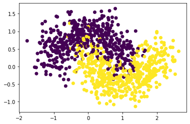

```python
X, y = make_moons(n_samples = 1000, noise = 0.3)
plt.scatter(X[:, 0], X[:, 1], c = y)
plt.show()
```

### 4.2.2 モデル評価・モデル選択のためのデータ分割

まずはモデルの評価のためのデータの分割を行います。

```python
X_train, X_test, y_train, y_test = train_test_split(X, y, test_size = 100)
X_train.shape, X_test.shape
```

```
((900, 2), (100, 2))
```

次に、評価時には学習に用いるデータを、モデル選択時に分割するためのクラスを準備します。

```python
kf = KFold(n_splits = 5)
```

### 4.2.3 モデル選択における目的関数の準備

最適化したいモデル評価の指標をハイパーパラメータで表現される関数の形で実装しておきましょう。今回は、5分割交差検証法における検証データでの平均正答率（mean accuracy score）をハイパーパラメータ`C`, `gamma`で説明する関数を目的関数に設定します。

```python
def objective(trial):
    # ハイパーパラメータの探索範囲の指定
    C = trial.suggest_loguniform("C", 1e-02, 1e+02)
    gamma = trial.suggest_loguniform("gamma", 1e-02, 1e+02)

    # 機械学習モデルのインスタンスを建てる
    svc = SVC(C = C, gamma = gamma, kernel = "rbf")

    # 5分割交差検証法での評価値の平均値を求める。
    # ここで、X = X_train, y = y_trainとしている点が大切。
    result = cross_validate(estimator = svc, X = X_train, y = y_train,
                            cv = kf, scoring = "accuracy")
    val_accuracy = result["test_score"].mean()

    return val_accuracy
```

### 4.2.4 `optuna`による最適化

`optuna`による最適化はシンプルで、次の2ステップを取ります。

1. 最適化問題の詳細を設定する。（特に最大値問題か最小値問題かの指定）
2. `optimize`メソッドに目的関数と繰り返し数を渡し、実際に最適解を求める。

```python
optuna.logging.set_verbosity(optuna.logging.WARNING)    # optunaのlogを非表示にする。
study = optuna.create_study(direction = "maximize")
study.optimize(objective, n_trials = 100)
study.best_params, study.best_value
```

```
({'C': 0.4847730423131618, 'gamma': 1.3000841999289656}, 0.9122222222222224)
```

また`optuna`には、ハイパーパラメータを一様に設定した時の目的関数の分散を、あるハイパーパラメータのみを動かすことでどれだけ説明できるか（分散説明率）によってハイパーパラメータの重要度を測るfunctional ANOVAが実装されています。

```python
# 補足 : functional ANOVAによるハイパーパラメータの重要度
fie = optuna.importance.FanovaImportanceEvaluator()
fie.evaluate(study)
```

```
OrderedDict([('gamma', 0.7820740258095523), ('C', 0.21792597419044762)])
```

### 4.2.5 選択したモデルの評価

得られたハイパーパラメータを実際に用いてサポートベクトル分類器を学習し、テストデータにおける正答率をチェックしておきましょう。

```python
svc = SVC(C = study.best_params["C"],
          gamma = study.best_params["gamma"],
          kernel = "rbf")
svc.fit(X_train, y_train)
```

```
SVC(C=0.4847730423131618, break_ties=False, cache_size=200, class_weight=None,
    coef0=0.0, decision_function_shape='ovr', degree=3,
    gamma=1.3000841999289656, kernel='rbf', max_iter=-1, probability=False,
    random_state=None, shrinking=True, tol=0.001, verbose=False)
```

```python
pred_train, pred_test = svc.predict(X_train), svc.predict(X_test)
accuracy_score(y_train, pred_train), accuracy_score(y_test, pred_test)
```

```
(0.9155555555555556, 0.93)
```

## 4.3 ハイパーパラメータ探索の理論

### 4.3.1 既存手法のレビュー

ハイパーパラメータ探索に用いられる手法の代表例として、

- Grid Search
- Random Search
- Nelder-Mead法
- Sequential Model-Based Optimization（SMBO）

が挙げられます。Nelder-Mead法とSMBOは、未知データに対する精度の推定値を与える関数 $\hat{m}(h)$ の最適化問題を解く手法である一方、Grid SearchやRandom Searchはハイパーパラメータの値の候補を手当たり次第に調べていく手法です。以下では、Grid SearchとRandom Searchについて簡単に復習し、Nelder-Mead法やSMBOとの違いを紹介します。

**Grid Search** : Grid Searchは、事前に各ハイパーパラメータについて探索する値の候補を決め、全ての組み合わせを虱潰しに試してみる方法のことです。

**Random Search** : Randomized Searchはハイパーパラメータ探索を指定した範囲でランダムに探す方法です。Grid Searchは、$n$個のハイパーパラメータに対して$m$個の値の候補があった場合、$m^n$通りの実験を行うことになります。しかし、$m^n$通りの実験を行うのであれば、ハイパーパラメータの値も$m^n$通り試した方が、精度向上に寄与するハイパーパラメータを見落としづらくなるのではないかという考えから生まれたものがRandom Searchです。

[figure not shown]

**手法の大まかな比較** : 最適解への収束の速さに注目して、ハイパーパラメータ探索の手法を比較しましょう。Grid SearchやRandom Searchは未知データに対する精度の推定値を与える関数 $\hat{m}(h)$ の情報を用いないため、解の探索回数がNelder-Mead法やSMBOより多くなることが期待されますが、一方で並列化が簡単というメリットがあります。Nelder-Mead法やSMBOにはこの逆が成り立つわけです。

### 4.3.2 Sequential Model-Based Optimization

#### SMBOのフレームワーク

ハイパーパラメータに応じた未知データの精度を表す関数 $m(h)$ を逐次的に推定することで、最適なハイパーパラメータ$h$ を探索使用という考え方をSequential Model-Based Optimizationといいます。以下、

- $h$ : ハイパーパラメータ
- $H$ : 探索したパラメータとそのときの精度のペアを集めた集合
- $m_t(h)$ : 未知データの精度を表す関数 $m(x)$ の$t$時点での推定
- $S(x,m_t(x))$ : 推定した関数 $m_{t}(h)$ からパラメータを評価する関数

とします。SMBOをより正確に定義すると、次のようなアルゴリズムに則って関数$M(x)$を近似する手法のことです。

1. 初期の推定結果 $m_0(h)$ を決めておく。
2. 以下を繰り返す。
   - $S(h,m_t(x))$の最大値を与えるハイパーパラメータ$h^*$を求める。
   - $h^{*}$での精度$m(h^*)$を求め、$(h^*,m(h^*))$を$H$に追加する。
   - $H$をもとに$m_t$を$m_{t+1}$に更新する。

精度の関数 $m_{t}$ の求め方・ハイパーパラメータの評価関数$S$に応じて、様々なSMBOが提案されています。今回はoptunaに採用されている精度の関数の推定方法である木構造的Parzen推定量（Tree-Structured Parzen Estimator）・パラメータの評価関数としてExpected Improvementを紹介します。

#### Expected Improvement

ハイパーパラメータの評価関数に、精度がとある値 $m^{*}$ からどれだけ改善するか見積もる**expected improvement**があります。ハイパーパラメータの値が$h$ のとき精度 $m$ がある閾値$m^*$に比べてどれだけ改善するかは

$$EI_{m^*}(h):=\int_{-\infty}^{\infty}\max(m-m^*, 0)p(m\mid h)dm$$

で計算できます。ここで、$p(m\mid h)$はハイパーパラメータ$h$ において精度 $m$ が得られる確信度を表す確率密度関数で、推定量 $m_{t}(h)$ に対応しています。なおoptunaでは、$H$に属する点の中から、上位$\gamma:=\lceil\min(0.25\sqrt{t},25)\rceil$に位置する精度の値を $m^*$ として用いています。

#### 木構造的Parzen推定量

$p(m\mid h)$ を推定する方法の一つに**木構造的Parzen推定量（TPE）** があります。木構造的Parzen推定量では、一度 $p(m\mid h)$ ではなく $p(h\mid m)$ 、要するに精度が $m$ だったときにそのハイパーパラメータが $m$ だった時の確信度をを定義します。TPEでは、まずここに

\begin{eqnarray*} p(h\mid m) &=& \begin{cases}l(h)\text{ if }y>m^*\\ g(h)\text{ if }y\leq m^* \end{cases} \end{eqnarray*}

という大胆な仮定を敷き、確率密度関数 $l(h)$, $g(h)$ を推定対象にします。

**確率密度関数 $l(h)$, $g(h)$ の推定** : ここが、精度の推定量 $m_{t}(h)$ の更新に対応しています。精度が$m^{*}$より大きい（resp. 以下）値を得る時のハイパーパラメータ $h$ の値の確信度は、実際にこれまでに観測された精度が$m^{*}$より大きい（resp. 以下）のハイパーパラメータ$h^{l}_{1},\cdots,h^{l}_{n}$から推定します。まずハイパーパラメータを小さい順に並べ

\begin{align*} \sigma_{i,m} &= \begin{cases} h_{1} - h_{min}\\ \max(h_{i+1}-h_{i}, h_{i}-h_{i-1})\\ h_{max} - h_{\gamma} \end{cases} \end{align*}

のband幅 $\sigma_{i}$ を持ち、中心を$h_{i}$とするGaussカーネルを等しい重みで足し合わせることで $l(h)$ をカーネル密度推定します。（注意 : 実際にはband幅のclipping、また下位の確率密度関数$g(h)$の推定時には下位25位点より精度が良いハイパーパラメータに対するカーネル密度推定の重みを減衰させる工夫を追加で行っていますが、改善点の多い部分だと考えられているため、ここでは省略します。）

**Expected Improvementの式変形** : 木構造的Parzen推定量をExpected Improvementの式に充てがうことで、次のような等式変形を得ることができます。

\begin{eqnarray*} EI_{m^*}(h) &=& \int_{-\infty}^{\infty}\max(m-m^*,0)p(m\mid h)dm\\ &=& \int_{-\infty}^{\infty}\max(m-m^*,0)\frac{p(h\mid m)p(m)}{p(h)}dm\\ &=& \frac{l(h)}{\gamma l(h)+(1-\gamma)g(h)}\int_{-\infty}^{\infty}\max(m-m^*, 0)p(m)dm\\ &\propto& \frac{1}{\gamma+(1-\gamma)\frac{g(h)}{l(h)}} \end{eqnarray*}

ここで、$p(x)=\gamma l(h)+(1-\gamma)g(h)$を用いました。この式は、要するにexpected improvement $EI_{m^{*}}(h)$ を最大にするハイパーパラメータ $h$ を求めることは、$g(h)/l(h)$ を最小化するハイパーパラメータの値を求めることと同じだということを意味します。

**探索候補の決定の仕方** : $g(h)/l(h)$ を最小化するハイパーパラメータの値を直接求めることが難しいため、探索するハイパーパラメータの値 $h$ を探索する際には精度が $m^*$ のときのハイパーパラメータの確信度を表す $l(h)$ の分布から複数個の点（例えばoptunaは24個）を乱数生成し、その中で、$g(h)/l(h)$の値が最も小さかったハイパーパラメータを次に探索するという方法を採用しています。